## CMB lensing map validation

Author: Patricia Larsen

In this jupyter notebook I am validating the mass sheets input to a CMB lensing map. These mass sheets are:

- z<3: the same lens plane mass maps used to create the galaxy lensing maps. These are created with a modified DTFE method from downsampled particle lightcones in cosmo-DC2.
- z>3: log-normal realisations of mass sheets, provided by Joachim Harnois-Deraps.

For now I combine these in a simple Born approximation, scaled with the lensing kernel and added without ray-tracing. This is provided in separate z<3 and z>3 maps so that we can properly check scaling consistency and swap out the higher redshift mass sheets if needed. Once these maps are properly validated we can apply ray-tracing.

```python
#dependencies
import numpy as np
import healpy as hp
import matplotlib.pyplot as plt
import pylab as plt
import pyccl as ccl
```

Read in the high and low redshift CMB lensing maps and plot them

```
NSIDE = 4096
ORDERING = RING in fits file
INDXSCHM = IMPLICIT
NSIDE = 4096
ORDERING = RING in fits file
INDXSCHM = IMPLICIT
```

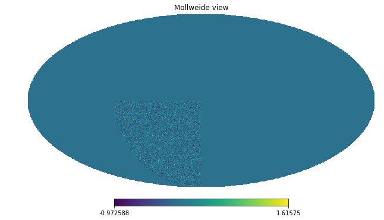

```python
map_lowz = hp.read_map('/global/projecta/projectdirs/lsst/groups/CS/cosmoDC2/mass_sheets_behind_z3/cmb_maps/cmblensmap_1_masked.fits')
map_hiz = hp.read_map('/global/projecta/projectdirs/lsst/groups/CS/cosmoDC2/mass_sheets_behind_z3/cmb_maps/cmblensmap_2_masked.fits')
hp.mollview(map_lowz+map_hiz)
```

Compute the angular power spectra of the maps (individual and combined)

```python
alm_cmb = hp.map2alm(map_lowz+map_hiz,lmax=2000)
cl_cmb = hp.alm2cl(alm_cmb)*8. # correcting for mask

alm_cmb1 = hp.map2alm(map_lowz,lmax=2000)
cl_cmb1 = hp.alm2cl(alm_cmb1)*8.

alm_cmb2 = hp.map2alm(map_hiz,lmax=2000)
cl_cmb2 = hp.alm2cl(alm_cmb2)*8.
```

Plot the results

```
(100, 2000)
```

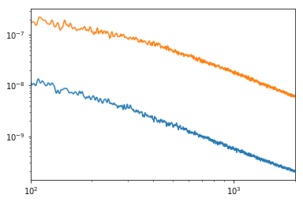

```python
plt.loglog(cl_cmb1) # low redshift
plt.loglog(cl_cmb2) # high redshift
plt.xlim([100,2000])
```

Compute theory from CCL

```python
cosmo = ccl.Cosmology(Omega_c=0.22, Omega_b=0.045, h=0.71, A_s=2.168e-9, n_s=0.96)
cmbl = ccl.CMBLensingTracer(cosmo, 1090.)
ell = np.arange(2, 2000)
cls_cmb = ccl.angular_cl(cosmo, cmbl, cmbl, ell)
```

Plot the results

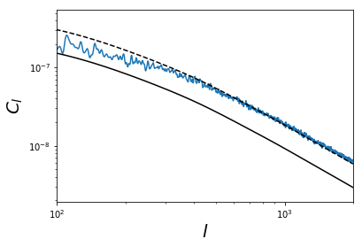

```python
plt.plot((cl_cmb))
plt.plot(ell, cls_cmb, 'k-') # factor of 2 out here for some reason
plt.plot(ell, cls_cmb*2., 'k--') # factor of 2 out here for some reason
plt.xscale('log')
plt.yscale('log')
plt.xlim([100,2000])
plt.xlabel(r'$l$', fontsize=20)
plt.ylabel(r'$C_l$', fontsize=20)
plt.show()
```

We clearly have an issue here, which looks like a scaling mismatch combined with lack of correlations between high redshift lens planes - we need to do a few things, validate that the low redshift values are correct, check the conventions of the outputs, and work out what is happening with the mass at high redshift. An obvious place to start is to look at the cross-correlation between CMB lensing and the DC2 galaxies

```python
from GCR import GCRQuery
import GCRCatalogs
```

```python
GCRCatalogs.available_catalogs
cosmodc2 = GCRCatalogs.load_catalog('cosmoDC2_v1.1.4_small')
```

```python
zlo = 1.0; zhi= 1.1;
mag_cut = 26;
filters = [(lambda z: (z > zlo) & (z < zhi), z)]  # Filter on selected redshift range
cosmodc2_data = cosmodc2.get_quantities(['convergence','redshift_true','ra_true','dec_true','mag_r'])#, filters=filters)
```

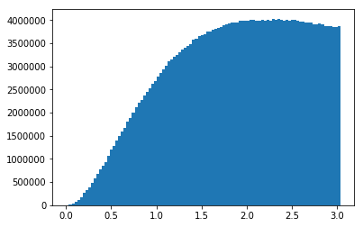

```python
plt.hist(cosmodc2_data['redshift_true'],bins=100);
plt.show()
```

```python
zlo = 1.0; zhi= 1.1;
zmask = (cosmodc2_data['redshift_true']<zhi)&(cosmodc2_data['redshift_true']>zlo)&(cosmodc2_data['mag_r']<mag_cut)
kappa = cosmodc2_data['convergence'][zmask]
ra = cosmodc2_data['ra_true'][zmask]
dec = cosmodc2_data['dec_true'][zmask]
print(len(kappa))
```

```
924156
```

Create a map of convergence values from the catalog

```python
pixnum = hp.ang2pix(2048,ra,dec,lonlat=True)
print(len(pixnum))
pixvals,counts = np.unique(pixnum, return_counts=True)
weightmap = np.zeros(hp.nside2npix(2048))
weightmap[pixvals] = counts
kappamap = np.zeros(hp.nside2npix(2048))
for i in range(len(pixnum)):
    kappamap[pixnum[i]]+=kappa[i]
for i in range(len(weightmap)):
    if weightmap[i]>0:
        kappamap[i] = kappamap[i]/weightmap[i]
```

```
924156
```

```
array([1.0005002 , 1.0015002 , 1.0025002 , 1.0035002 , 1.00450019,
       1.00550019, 1.00650019, 1.00750018, 1.00850018, 1.00950018,
       1.01050017, 1.01150017, 1.01250017, 1.01350017, 1.01450016,
       1.01550016, 1.01650016, 1.01750015, 1.01850015, 1.01950015,
       1.02050014, 1.02150014, 1.02250014, 1.02350014, 1.02450013,
       1.02550013, 1.02650013, 1.02750012, 1.02850012, 1.02950012,
       1.03050011, 1.03150011, 1.03250011, 1.0335001 , 1.0345001 ,
       1.0355001 , 1.0365001 , 1.03750009, 1.03850009, 1.03950009,
       1.04050008, 1.04150008, 1.04250008, 1.04350007, 1.04450007,
       1.04550007, 1.04650007, 1.04750006, 1.04850006, 1.04950006,
       1.05050005, 1.05150005, 1.05250005, 1.05350004, 1.05450004,
       1.05550004, 1.05650004, 1.05750003, 1.05850003, 1.05950003,
       1.06050002, 1.06150002, 1.06250002, 1.06350001, 1.06450001,
       1.06550001, 1.06650001, 1.0675    , 1.0685    , 1.0695    ,
       1.07049999, 1.07149999, 1.07249999, 1.07349998, 1.07449998,
       1.07549998, 1.07649998, 1.07749997, 1.07849997, 1.07949997,
       1.08049996, 1.08149996, 1.08249996, 1.08349995, 1.08449995,
       1.08549995, 1.08649995, 1.08749994, 1.08849994, 1.08949994,
       1.09049993, 1.09149993, 1.09249993, 1.09349992, 1.09449992,
       1.09549992, 1.09649992, 1.09749991, 1.09849991, 1.09949991])
```

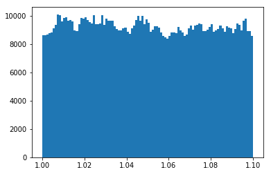

```python
#hp.mollview(kappamap)
#plt.show()
nz,zs,b= plt.hist(cosmodc2_data['redshift_true'][zmask],bins=100)
zv = (zs[1:]-zs[:-1])/2. + zs[:-1]
zv
```

```python
alm_kappa = hp.map2alm(kappamap,lmax=2000)
fsky1 = 8; fsky2 = np.sum(kappamap!=0)/(np.shape(kappamap)[0]+0.0)
cl_kappa_cmb = hp.alm2cl(alm_kappa,alm_cmb2)/np.sqrt(fsky1*fsky2)
```

```python
lens1 = ccl.WeakLensingTracer(cosmo, dndz=(zv, nz))
cls_cross = ccl.angular_cl(cosmo, lens1, cmbl, ell)
```

```python
print(cl_kappa_cmb)

#plt.loglog(cls_cross)
```

```
[ 1.23654569e-10 -1.63125256e-10 -7.64017021e-11 ...  3.00799117e-12
  3.39658905e-12  3.90717953e-12]
```

```python
fsky2
```

```
0.0013846556345621746
```

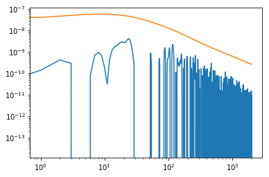

```python
plt.loglog(cl_kappa_cmb)
plt.loglog(cls_cross)
```